# Collaborative Development of Efficient R Packages

# 5 Typical Usage: Pull, Commit, and Push

Almost every time, your version-tracking routine should be in the following steps:

1. Pull new commits from GitHub to your local directory.
2. Make changes.
3. Commit your changes.
4. If necessary, resolve conflicts.
5. Push your changes back to GitHub.

Recall my `testPackage` repository I had pushed to GitHub.

[figure not shown]

I decide that this project needs a README file, so I click the **Add a README** button, and write a brief message to myself and any other users.

[figure not shown]

At the bottom of the page, I see GitHub’s version of RStudio’s “Review Changes” window:

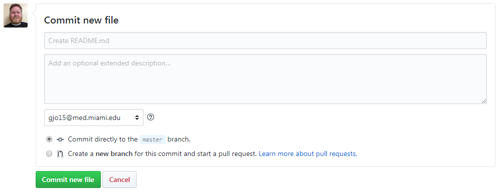

Write a commit message, just like before, and click **Commit new file**.

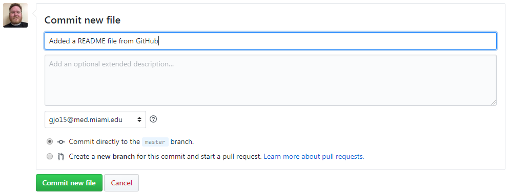

The repository page on GitHub comes back, but this time with a few changes:

1. The *latest commit* message (in the blue ribbon at the top of the directory) has changed from “First Commit. Hello Git!” to “Added a README file from GitHub”.
2. The time stamp of the latest commit changed too.
3. The README.md file was added to the directory, and its commit message and time stamp are different from the other files.
4. The README that I wrote is displayed on the package repository home page.

[figure not shown]

## 5.1 Pull New Changes

However, look at my package directory on my local machine. The README.md file isn’t there.

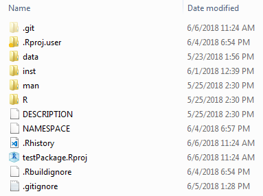

In order to update the state of my local files to match the state of the files on GitHub, I need to *pull* the changes to my local machine. **THIS NEXT STATEMENT IS VERY IMPORTANT: GitHub gives priority to changes that have been *committed* over uncommitted changes on your local machine.** This means that you should *always pull first*. My common practice on collaborative projects is to pull changes every morning, work for a few hours, commit my updates, pull again to catch any new changes, then push my changes to GitHub. I will repeat this *pull* > *work* > *commit* > *push* dance 2-3 times during the day.

Because I know there are new files in my repository on GitHub that I don’t have on my local machine, I *pull* these changes.

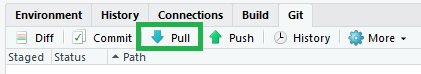

Git informs me of which files have been changed. This message tells me that the README.md file was changed: it went from 0 lines (an empty file) to 4 lines. Then, this message gives me a summary of the changes: the README.md file was “created”.

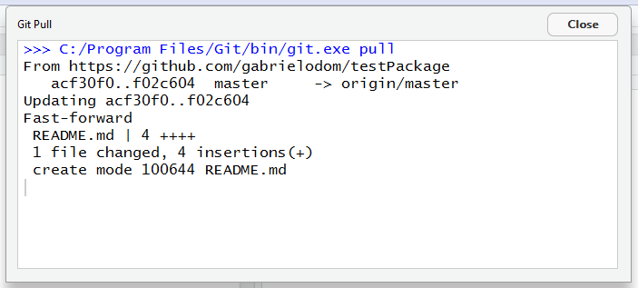

After I’ve read through the changes, I close the window. I now see the README.md file in my package working directory.

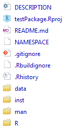

## 5.2 Commit your Changes

We probably need a little more in the README, so I’ll edit that file.

[figure not shown]

After you’ve made the changes you want, you can preview the changes with the **Preview** button. If you make edits to a function, I recommend that you always test your code or package before committing and pushing your changes to GitHub. As much as possible, you want the code you have on GitHub to be error-free. This means that you should try to make edits to a package or pipeline one small piece at a time, so that each change you make can be thoroughly checked. Of course, there are time where this isn’t possible, but you should consider this a “best practice” advisory.

Save the changes you’ve made. When you do, the file will appear on the **Git** tab of the **Environment Pane**. Before, the icon next to files was a green box with an “A” in it. This meant that the files were *added*. Now we see a blue box with an “M” in it. This means the file has been *modified*.

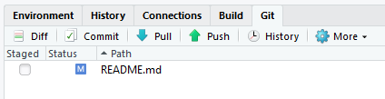

When you are confident that the changes you have made are correct, select the files you wish to commit.

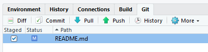

Click the **Commit** button. The **RStudio: Review Changes** window pops up. The top left panel shows the files you’ve chosen to commit to Git. The bottom panel shows the changes for the selected file. Additions are in shaded in green; deletions are shaded in red. The top right panel shows the commit message I wrote for these edits. Click **Commit**.

[figure not shown]

After committing these changes, Git informs you an overview of what you changed. Also, Git now tells you “Your branch is ahead of ‘origin/master’ by 1 commit”. This is there to remind you that—while your changes are committed—they aren’t on GitHub yet. Close these two windows.

[figure not shown]

## 5.3 Push your Changes

Now that you’ve made your edits and checked that they all work, it’s probably been a few hours. It’s conceivable that one of your collaborators has pushed some changes out to your repository on GitHub. Before we push our edits, we should click **Pull** again to check for any new changes.

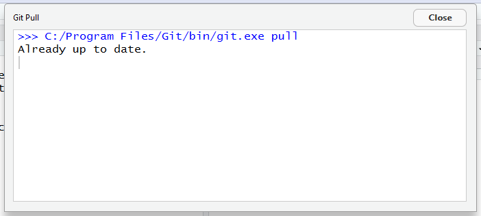

We have no changes to worry about being overwritten. **Note: this is why I recommend that you write each function in its own script. This way, many people can collaborate on different pieces of a project without accidentally overwriting changes or constantly having to merge changes to the same file.** We can push our changes now, then close the pop-up window. Our changes have been successfully stored on GitHub.

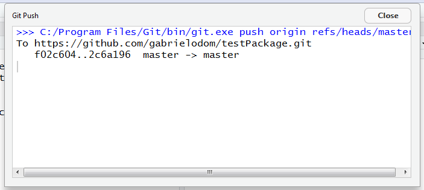

# 6 Documenting Project Changes

One of my colleagues credits audit trails as the primal form of software documentation. In these trails, people would leave messages in the project file answering these four questions:

1. What is the change?
2. Who is making this change?
3. When did they make this change?
4. Why did they make this change?

These are the topics that should be included in **every commit message**. We will cover each with some detail pertaining to development with RStudio and GitHub.

As an aside, this section will not even scratch the surface of true software project documentation. That topic dives farther into project management than I am comfortable covering. However, the [IEEE Standard for Software Project Management Plans](http://sce2.umkc.edu/BIT/burrise/pl/appendix/Software_Documentation_Templates/IEEEProjPlan.pdf) covers this topic with excruciating detail. If you are very interested in developing these skills, [Coursera](https://www.coursera.org/specializations/product-management) and [Pluralsight](https://www.pluralsight.com/courses/technical-writing-software-documentation) both offer courses on software project organization and documentation.

## 6.1 The Old Changelog System

The good news for us is: RStudio and Git handle three of the four main questions automatically. You should keep track of the “before-and-after” of each change your team makes anywhere in the project. If you had to do this by hand, you might have a change log entry that says

> User `@steve_k` changed lines 114-117 of file `such_and_such.R` from “blah blah blah” to “bippity boppity boo” on 20161121 at 1806 hours. End user requested this enhancement via support request #233 on 20161108. This closes #233.

Looks exhausting, right? Let’s break down this fictional changelog entry.

## 6.2 What

The **What** of this entry is twofold

> changed lines 114-117 of file `such_and_such.R` from “blah blah blah” to “bippity boppity boo”

> This closes #233.

We see that a change was made, rather than an addition or deletion. We see which lines were changed and from which file. We see what those lines said before the change, and what they said after. For us, all of these “what” questions are answered automatically by Git. Remember the red and green highlighted lines when we committed a file? That is the answer to the questions of “what did the file say before?” and “what did the file say after?” without us putting in any extra work.

The second point is to the other developers that issue number 233 has been solved. GitHub is very smart about closing issues. If you have an issue ticket [logged through GitHub](https://help.github.com/articles/creating-an-issue/), you can use your commit message to close the pertinant issue ticket with the `closes #<TICKET NUMBER>` syntax.

## 6.3 Who

The **Who** of this entry is

> User `@steve_k`

We know who this person is, and we can track them down if their change was innapropriate, documented poorly, or broke the code somewhere downstream. This is handled through the GitHub account you created. I can go through all of the commits that `@steve_k` made to this repository. For any software “crimes”, this account is your digital fingerprint.

## 6.4 When

The **When** of this entry is

> on 20161121 at 1806 hours

Once again, recall our repository on GitHub: all of the commits we made were time-stamped. I can go back through my projects and find out exactly when I made a certain change, or when the last time my colleague Steve made a change to his part of the project.

## 6.5 Why

The **Why** of this entry is

> End user requested this enhancement via support request #233

When documenting changes with Git, the *why* is the most important piece. This is because the *what*, *who*, and *when* are documented automatically. Just like code comments should describe *why* you have written a function in a certain way—rather than *what* you wrote, change commit messages should also answer *why*. Make sure that your commit message is consise. If you find that you need a lot of documentation to explain why you made a change, then write this paragraph in a development notes file, and reference the section of that file in your commit message: “see `dev_notes.txt` section 2.1.1 for commit notes”.

After changing to modern commit messages, the original message can be simplified from

> User `@steve_k` changed lines 114-117 of file `such_and_such.R` from “blah blah blah” to “bippity boppity boo” on 20161121 at 1806 hours. End user requested this enhancement via support request #233 on 20161108. This closes #233.

to

> Completed end user enhancement request. Closes #233.

The **what**, **who**, and **when** is recorded automatically. This is much simpler!

## 6.6 GitHub Issue Tracking

We briefly mentioned that GitHub has a useful set of tools for tracking questions and areas of improvement with your project. These are called **Issues**. To create a new issue for your team to work on, go to the GitHub repository for your project, and click on the **Issues** tab. This window shows all of the development points for your project that you or someone else has logged.

[figure not shown]

### 6.6.1 Create a New Issue

I know that the `MakeWaffle()` function in the `testPackage` package needs a little work. Despite this shortcoming, currently my test package does not have any logged issues. Thus, I will create one. Click the **New issue** button.

This window looks somewhat similar to the GitHub commit window from when we added the README file. We have fields for the issue title (**Title**), our description of the issue (**Leave a comment**), who we will assign to fix the problem (**Assignees**), the category of the problem (**Labels**), and whether or not this issue belongs to a certain part of the development track (**Projects** or **Milestone**).

[figure not shown]

I give the issue a title, a brief (but detailed) description, and assign it to myself.

[figure not shown]

Because there are two pieces of this issue—the missing `title` value and the improper use of the `is.null()` check—I add two labels: **bug** and **enhancement**, respectively. Software “bugs” are problems with the code that arise under normal use. Most `plot()` functions in R can draw their title from the object passed to them automatically. People would expect the same behavior of our waffle plot function, so this is a bug. The code fails to execute in a situation that would be common for the end user. Software “enhancements” are places to make functioning code better. There isn’t a flaw in the code (that would be a “bug”), but users or developers think that the code should do more or do some task in a different or (hopefully) better way.

One other point: the issue description supports text styling with [Markdown](https://www.markdownguide.org/). This is a light-weight text markup language; this means that the computer treats it like code, but it’s entirely human-readable. For questions on this, please ask Dr. James Ban for his excellent beginner’s guide to RMarkdown.

Now that I’ve written, labelled, and assigned this issue, I can *submit* it. Click **Submit new issue**. Notice that GitHub marks this as “Issue #1”. Remember this, because we’ll need it later.

[figure not shown]

### 6.6.2 Fix the Issue

We have identified the issue and logged it. At this point in the development cycle, we would normally spend some time trying to figure out how to fix the issue. However, because this is an example, we have relatively little work cut out for us.

Here’s the old `MakeWaffle()` function.

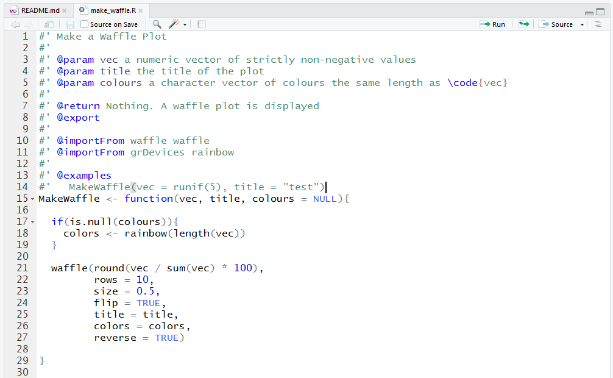

Here are my changes. I rebuild the package with this updated version, text that it works as intended, and rebuild the package documentation.

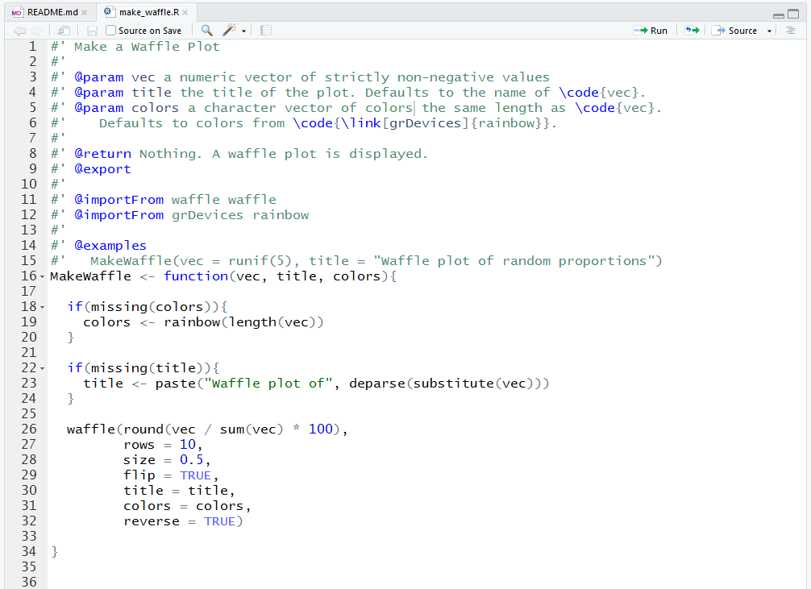

Despite the triviality of this issue, we have highlighted five major steps to developing or improving software:

1. Identify an issue.
2. Identify a solution.
3. Implement the solution.
4. Test the solution.
5. Document the solution.

### 6.6.3 Commit to Close the Issue

Now that I’ve tested and documented my solution, I’m condfident that it solves the problem outlined in *Issue #1* on GitHub. I will now tick the box next to the script AND the manual files, and click **Commit**.

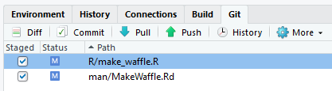

Our old friend, the **RStudio: Review Changes** window, appears. All of this is as we would expect it. The only difference is an addition to the commit message: “closes #1”. I add this to my commit message to inform GitHub that the changes I’m committing will solve the problem outlined in Issue #1. I write an informative commit message and click **Commit** again.

[figure not shown]

As before, the changes are not on GitHub until I *push* them. Click **Push**.

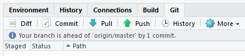

Now, GitHub shows that the issue has been resolved. I can click on the `f0a7b87` hyperlink in the closing message to see [my commit](https://github.com/gabrielodom/testPackage/commit/f0a7b871afe574a395f0c3a01e68d71087325ce3) on GitHub.

[figure not shown]

Finally, we can go back to the main **Issues** tab of the package repository to see that our issue is indeed closed.

[figure not shown]

# 7 Conclusion

Between the last lesson and this lession, I hope that you have a much better appreciation for how much time and thought should go in to *organizing* a project before you and your team ever write your first function. We have covered in this lesson an overview of directory organiation (applicable to both shared directories and version-controlled projects). We covered some of the basics of connecting RStudio to GitHub, as well as some of the main actions to version-control your projects and packages. Finally, we briefly discussed the four main questions to answer at every major and minor implementation step: what, who, when, and why—and how Git helps us answer those questions with relative ease.